# Actividad 3: Análisis de un caso práctico en R

Grupo 9 Lote 7 - Máster Bioinformática UNIR - Estadística y R

2025-01-26 - Curso 2024-2025

## Objetivos de la actividad

Para la realización de la actividad, se cargará el dataset de interés «Dataset expresión genes.csv», el cual se trata de una base de datos de 65 pacientes que contiene información de la expresión de 46 genes con diferentes funciones. Además de estas variables, contiene otras variables de interés como el tratamiento (A o B) que siguen cada paciente, tipo de tumor que tienen (colorrectal, pulmón y mama) y la extensión tumoral (localizado, metastásico o regional). Por último, se recoge información de variables bioquímicas, síntomas y otras variables sociodemográficas.

## Resolución de ejercicios

### Ejercicio 1

El primer ejercicio consiste en abrir, explorar y preprocesar la base de datos utilizando las funciones vistas para cargar, explorar y analizar la base de datos en formato CSV.

```r
# Cargar el csv de expresión génica
datos <- read.csv("./data/expresion genes.csv")

# Con el dataset cargado, observaremos los datos y su estructura:
#head(datos)
#str(datos)
#summary(datos)

# Y verificaremos si hay algun valor missing (NA)

#is.na(datos)
#colSums(is.na((datos)))
#rowSums(is.na(datos))

# Al no haber ningún valor faltante, se puede seguir con el desarollo de la actividad.
```

### Ejercicio 2 y 3: Aplicar un PCA con gráficos descriptivos

Para ello, se ilustrarán cada uno de los pasos que se vieron en el temario y en clase, creando tablas o figuras de cada uno de ellos:

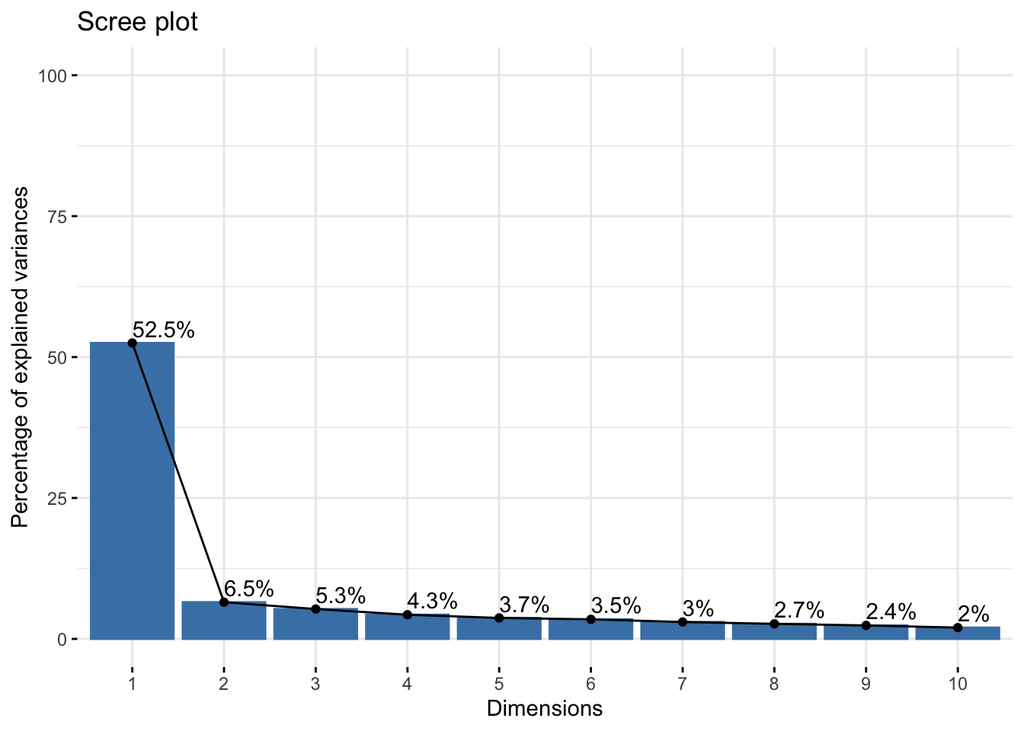

```r
#Sacar las columnas X e id del dataset original:
datos <- datos %>%
  select(-X, -id)

# Seleccionar únicamente las columnas de expresión génica para hacer el PCA
genes <- datos %>%
  select(starts_with("AQ_"))

# Estandarizar los datos utilizando scale
genes_escalados <- scale(genes)

# Realizar el PCA
pca <- prcomp(genes_escalados, center = TRUE, scale. = TRUE)

# Resumen del PCA (se puede ver el resumen descomentando el summary para la PCA)
#summary(pca)

# Extraer la varianza explicada, construcción de un Scree plot
fviz_eig(pca, addlabels = TRUE, ylim = c(0, 100))
```

A continuación, se realizará un gráfico de cargas para las distintas variables utilizando su contribución para los distintos colores del gráfico, también utilizando factoextra.

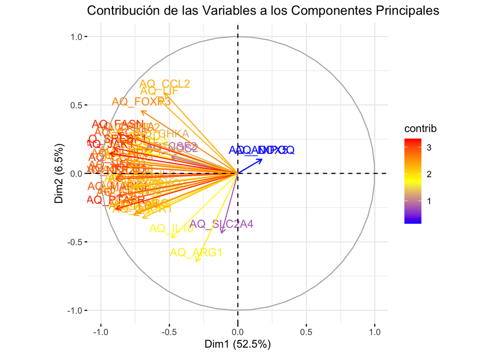

```r
# Gráfico de las variables (cargas) con colores según su contribución
fviz_pca_var(pca,
             col.var = "contrib",  # Colorear las variables según su contribución
             gradient.cols = c("blue", "yellow", "red"),
             title = "Contribución de las Variables a los Componentes Principales")
```

Otra forma de analizar los distintos componentes principales, podría ser a partir de la clusterización por grupos con el k-means:

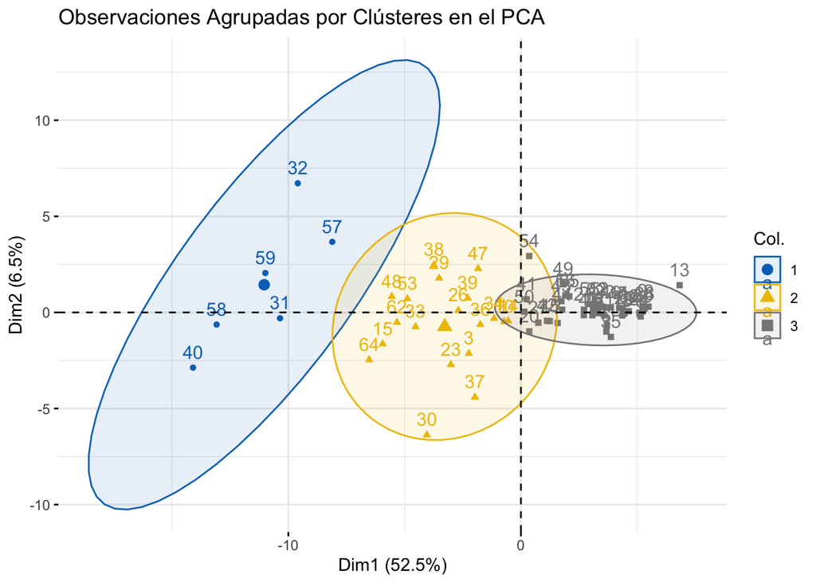

```r
#También podemos realizar una agrupación por clustering de variables:

# Aplicar k-means con k=3, para detectar 3 grupos distintos:
set.seed(123)  # Fijar semilla para reproducibilidad
kmeans_resultado <- kmeans(pca$x[, 1:2], centers = 3)  # Usar los primeros dos componentes

# Gráfico de las observaciones (puntuaciones) con los clústeres
fviz_pca_ind(pca,
             col.ind = factor(kmeans_resultado$cluster),
             palette = "jco",  # Paleta de colores
             addEllipses = TRUE,  # Agregar elipses de confianza para los clústeres
             title = "Observaciones Agrupadas por Clústeres en el PCA")
```

De esta forma, observamos cómo las observaciones (individuos) se agrupan en el espacio definido por los dos primeros componentes principales dónde los puntos representan cada paciente y se puede observar a simple vista su agrupación a través de la técnica de clusterización.

Coincidiendo con los gráficos anteriores, el eje Dimensión 1 parece ser el principal discriminante entre los clusters, mientras que Dimensión 2 añade algo de información secundaria. Además, podemos observar tres grupos principales (clusters 1, 2, y 3):

La posición relativa de los clusters indica que el Cluster 1 está más diferenciado en Dim1, mientras que los Clusters 2 y 3 están más cercanos y pueden compartir características similares.

También se han realizado otros gráficos cómo *gráficos de barras de las cargas* de cada variable pero se excluirán del análisis por no explicar bien las diferencias entre dimensiones.

### Ejercicio 4: Crear una tabla descriptiva con las variables importantes

Para calcular los terciles de un conjunto de datos, primero se determinará los puntos de corte que dividen el conjunto en tres partes iguales utilizando la función *quantile* y se asignará a cada dato una categoría del tercil, utilizando la función *cut*:

```r
# Crear terciles para los componentes principales con quantile y cut:
datos <- datos %>%
  mutate(
    PC1_tercile = cut(pca$x[, 1], breaks = quantile(pca$x[, 1], probs = c(0, 0.33, 0.66, 1)),
                      labels = c("t1", "t2", "t3"), include.lowest = TRUE),
    PC2_tercile = cut(pca$x[, 2], breaks = quantile(pca$x[, 2], probs = c(0, 0.33, 0.66, 1)),
                      labels = c("t1", "t2", "t3"), include.lowest = TRUE)
  )

# Seleccionar solo las variables de genes y los terciles
genes <- datos %>% select(starts_with("AQ_"), PC1_tercile, PC2_tercile)
```

Una vez categorizados los diferentes datos para cada tercil y seleccionados los datos de expresión génica, se procederá a realizar la tabla descriptiva utilizando *gtsummary*, usando en primer lugar la función tbl_summary con by, statistic, type y digits; y add_p con test y pvalue_fun:

```r
# Generar tabla descriptiva para el Componente 1
tbl_PC1 <- genes %>%
  tbl_summary(
    by = PC1_tercile,  # Agrupar por terciles del Componente 1
    statistic = all_continuous() ~ "{mean} ({sd})",  # Media y desviación estándar
    digits = all_continuous() ~ function(x) format(x, digits = 2, scientific = TRUE)
  ) %>%
  add_p(
    test = all_continuous() ~ "kruskal.test",  # Prueba de Kruskal-Wallis
    pvalue_fun = function(x) sprintf("%.3f", x)  # Formato decimal para valores p
  )

# Generar tabla descriptiva para el Componente 2
tbl_PC2 <- genes %>%
  tbl_summary(
    by = PC2_tercile,  # Agrupar por terciles del Componente 2
    statistic = all_continuous() ~ "{mean} ({sd})",  # Media y desviación estándar
    digits = all_continuous() ~ function(x) format(x, digits = 2, scientific = TRUE)
  ) %>%
  add_p(
    test = all_continuous() ~ "kruskal.test",  # Prueba de Kruskal-Wallis
    pvalue_fun = function(x) sprintf("%.3f", x)  # Mostrar valores p con 3 decimales
  )
```

Una vez generados los dos datasets de forma independiente para las dos componentes, se procederá a juntar las tablas con la función *tbl_merge* creando una lista para las dos tablas anteriores y obtener así una tabla parecida a la requerida por el enunciado de la práctica:

```r
# Combinar ambas tablas
tbl_combinadas <- tbl_merge(
  tbls = list(tbl_PC1, tbl_PC2),
  tab_spanner = c("**Component 1**", "**Component 2**")
)

# Añadir el título a la tabla
tbl_combinadas <- tbl_combinadas %>%
  modify_caption("**Tabla descriptiva de genes agrupados por terciles**")

tbl_combinadas
```

**Tabla descriptiva de genes agrupados por terciles**

| **Characteristic** | **Component 1** **t1** N = 22<sup>1</sup> | **Component 1** **t2** N = 21<sup>1</sup> | **Component 1** **t3** N = 22<sup>1</sup> | **Component 1** **p-value**<sup>2</sup> | **Component 2** **t1** N = 22<sup>1</sup> | **Component 2** **t2** N = 21<sup>1</sup> | **Component 2** **t3** N = 22<sup>1</sup> | **Component 2** **p-value**<sup>2</sup> |
| --- | --- | --- | --- | --- | --- | --- | --- | --- |
| AQ_ADIPOQ | 2.3e-09 (5.5e-09) | 4.2e-10 (5.4e-10) | 4.5e-02 (2.1e-01) | 0.110 | 8.6e-10 (1e-09) | 3.5e-10 (3.8e-10) | 4.5e-02 (2.1e-01) | 0.417 |
| AQ_ALOX5 | 1.4e-04 (6.9e-05) | 5.1e-05 (3.6e-05) | 2.1e-05 (1.5e-05) | 0.000 | 1e-04 (7.2e-05) | 3.5e-05 (3.4e-05) | 7.1e-05 (7e-05) | 0.002 |
| AQ_ARG1 | 6.8e-06 (7e-06) | 2.9e-06 (3.5e-06) | 2.4e-06 (3.6e-06) | 0.002 | 8.4e-06 (6.8e-06) | 1.8e-06 (1.7e-06) | 1.8e-06 (2.8e-06) | 0.000 |
| AQ_BMP2 | 1e-07 (7.6e-08) | 4e-08 (4e-08) | 2e-08 (3.2e-08) | 0.000 | 8.1e-08 (7.1e-08) | 3.1e-08 (6.2e-08) | 4.9e-08 (4.6e-08) | 0.002 |
| AQ_CCL2 | 2.5e-07 (2.9e-07) | 9e-08 (1.4e-07) | 1.5e-08 (1.3e-08) | 0.000 | 9.1e-08 (1.2e-07) | 4.6e-08 (7e-08) | 2.1e-07 (3.2e-07) | 0.019 |
| AQ_CCL5 | 1.1e-03 (5.9e-04) | 3.6e-04 (2.3e-04) | 1.2e-04 (7.1e-05) | 0.000 | 6.9e-04 (5e-04) | 2.8e-04 (4.3e-04) | 5.7e-04 (6.2e-04) | 0.004 |
| AQ_CCR5 | 1.9e-05 (1.2e-05) | 6.6e-06 (3.2e-06) | 2.2e-06 (1.7e-06) | 0.000 | 1.1e-05 (1.1e-05) | 3.5e-06 (2.8e-06) | 1.3e-05 (1.2e-05) | 0.001 |
| AQ_CD274 | 3.7e-06 (2e-06) | 1.5e-06 (1.4e-06) | 5.3e-07 (3.9e-07) | 0.000 | 3e-06 (2.6e-06) | 1.1e-06 (1.2e-06) | 1.6e-06 (1.2e-06) | 0.008 |
| AQ_CD36 | 5e-05 (1.9e-05) | 2.8e-05 (1.8e-05) | 7.9e-06 (5.1e-06) | 0.000 | 4.2e-05 (2.5e-05) | 1.2e-05 (9.4e-06) | 3.1e-05 (2.2e-05) | 0.000 |
| AQ_CHKA | 1.2e-06 (9.7e-07) | 7e-07 (5.1e-07) | 2.8e-07 (4e-07) | 0.001 | 8.8e-07 (6.3e-07) | 3.3e-07 (4e-07) | 9.9e-07 (1e-06) | 0.010 |
| AQ_CPT1A | 1.8e-05 (9.5e-06) | 7.1e-06 (5.1e-06) | 2.4e-06 (1.8e-06) | 0.000 | 1.1e-05 (8e-06) | 4.3e-06 (4.2e-06) | 1.2e-05 (1.2e-05) | 0.007 |
| AQ_CSF2 | 4.8e-08 (4.6e-08) | 3.4e-08 (4.1e-08) | 7.2e-09 (1.2e-08) | 0.004 | 3.1e-08 (3.8e-08) | 1.8e-08 (3.4e-08) | 4e-08 (4.5e-08) | 0.400 |
| AQ_CXCR1 | 3.8e-05 (2.6e-05) | 1.2e-05 (8e-06) | 5e-06 (3.2e-06) | 0.000 | 3.1e-05 (2.6e-05) | 8.7e-06 (1.6e-05) | 1.5e-05 (1.4e-05) | 0.000 |
| AQ_FASN | 8.3e-06 (4.3e-06) | 3.4e-06 (1.3e-06) | 7.5e-07 (5.6e-07) | 0.000 | 4.5e-06 (3.4e-06) | 2e-06 (3e-06) | 5.8e-06 (4.7e-06) | 0.001 |
| AQ_FOXO3 | 2.9e-04 (1.7e-04) | 1.8e-04 (1.5e-04) | 8e-05 (4.5e-05) | 0.000 | 2.8e-04 (2e-04) | 1.3e-04 (8.7e-05) | 1.4e-04 (1.2e-04) | 0.011 |
| AQ_FOXP3 | 3.5e-06 (3.2e-06) | 1.2e-06 (5.7e-07) | 2.6e-07 (2e-07) | 0.000 | 1.5e-06 (1.3e-06) | 6.8e-07 (1.2e-06) | 2.7e-06 (3.3e-06) | 0.001 |
| AQ_G6PD | 7.8e-05 (3.8e-05) | 3.5e-05 (1.2e-05) | 1.4e-05 (8.8e-06) | 0.000 | 6.3e-05 (4e-05) | 2.3e-05 (2.1e-05) | 4e-05 (3.3e-05) | 0.000 |
| AQ_GPD2 | 5.1e-06 (3.3e-06) | 1.7e-06 (1.2e-06) | 7.8e-07 (6.1e-07) | 0.000 | 2.8e-06 (2.3e-06) | 1.2e-06 (1.4e-06) | 3.5e-06 (3.7e-06) | 0.022 |
| AQ_GPX1 | 1.4e-04 (6.5e-05) | 9.1e-05 (5.2e-05) | 6.1e-05 (3.6e-05) | 0.000 | 1.3e-04 (5.9e-05) | 9.1e-05 (6.5e-05) | 7.2e-05 (4.5e-05) | 0.007 |
| AQ_IFNG | 6.8e-07 (5.4e-07) | 2.4e-07 (1.4e-07) | 8.6e-08 (1e-07) | 0.000 | 4.4e-07 (4.9e-07) | 1.6e-07 (1.9e-07) | 4.1e-07 (4.4e-07) | 0.071 |
| AQ_IL10 | 2.1e-07 (2.9e-07) | 7.4e-08 (1.1e-07) | 1.6e-08 (1.4e-08) | 0.000 | 1.9e-07 (3.1e-07) | 3.3e-08 (3.6e-08) | 7.1e-08 (7.8e-08) | 0.022 |
| AQ_IL1B | 2.8e-05 (1.9e-05) | 9.4e-06 (5.9e-06) | 3.2e-06 (2.8e-06) | 0.000 | 2.3e-05 (2.1e-05) | 7.6e-06 (1.2e-05) | 1e-05 (8.4e-06) | 0.000 |
| AQ_IL6 | 6.5e-08 (7.7e-08) | 1.8e-08 (1.9e-08) | 8.5e-09 (1.4e-08) | 0.001 | 3.6e-08 (5.4e-08) | 2.6e-08 (6.6e-08) | 2.9e-08 (3.6e-08) | 0.644 |
| AQ_IRS1 | 2.2e-07 (1.3e-07) | 1.3e-07 (7.6e-08) | 4.5e-08 (2.6e-08) | 0.000 | 1.7e-07 (1.3e-07) | 8.2e-08 (8e-08) | 1.4e-07 (1.2e-07) | 0.007 |
| AQ_JAK1 | 2.2e-04 (9e-05) | 8.8e-05 (2.7e-05) | 2.8e-05 (1.5e-05) | 0.000 | 1.3e-04 (8e-05) | 6.5e-05 (9.7e-05) | 1.4e-04 (1e-04) | 0.001 |
| AQ_JAK3 | 6.3e-05 (5.3e-05) | 1.9e-05 (1.1e-05) | 6.8e-06 (5.3e-06) | 0.000 | 4.6e-05 (5.8e-05) | 1.2e-05 (1.2e-05) | 3.1e-05 (2.4e-05) | 0.004 |
| AQ_LDHA | 5.4e-05 (2.2e-05) | 2.7e-05 (1.3e-05) | 1e-05 (6.6e-06) | 0.000 | 3.5e-05 (2.4e-05) | 1.5e-05 (1.3e-05) | 4e-05 (2.5e-05) | 0.000 |
| AQ_LIF | 4.1e-08 (4.7e-08) | 1.9e-08 (2.2e-08) | 5.4e-09 (5.8e-09) | 0.040 | 1.5e-08 (2.6e-08) | 1.1e-08 (1.5e-08) | 3.9e-08 (4.5e-08) | 0.013 |
| AQ_MAPK1 | 5.3e-05 (2.1e-05) | 2.1e-05 (1.1e-05) | 8e-06 (6.4e-06) | 0.000 | 4.3e-05 (2.7e-05) | 1.3e-05 (1.4e-05) | 2.6e-05 (1.9e-05) | 0.000 |
| AQ_NFE2L2 | 6.3e-05 (2.8e-05) | 2.1e-05 (1.3e-05) | 8.7e-06 (7.3e-06) | 0.000 | 4.4e-05 (3e-05) | 1.8e-05 (2.2e-05) | 2.9e-05 (3e-05) | 0.009 |
| AQ_NFKB1 | 3.1e-05 (1e-05) | 1.3e-05 (7.7e-06) | 3.2e-06 (3.4e-06) | 0.000 | 2.1e-05 (1.1e-05) | 7.4e-06 (1.3e-05) | 1.8e-05 (1.4e-05) | 0.000 |
| AQ_NLRP3 | 1.3e-05 (6.5e-06) | 5.2e-06 (2.7e-06) | 1.6e-06 (8.6e-07) | 0.000 | 9e-06 (6.9e-06) | 3.4e-06 (3.9e-06) | 7.7e-06 (6.8e-06) | 0.002 |
| AQ_NOS2 | 6.1e-09 (7.9e-09) | 2.5e-09 (3.2e-09) | 7.1e-10 (1.4e-09) | 0.008 | 4.4e-09 (6.3e-09) | 1.9e-09 (4.7e-09) | 3e-09 (5.2e-09) | 0.448 |
| AQ_NOX5 | 6e-09 (1.2e-08) | 4.8e-09 (8.2e-09) | 4.5e-02 (2.1e-01) | 0.262 | 7.4e-09 (1.3e-08) | 2.1e-09 (4.2e-09) | 4.5e-02 (2.1e-01) | 0.347 |
| AQ_PDCD1 | 3.7e-06 (3.4e-06) | 9.8e-07 (5e-07) | 3.5e-07 (3.9e-07) | 0.000 | 1.9e-06 (2.4e-06) | 5.7e-07 (5.6e-07) | 2.6e-06 (3.3e-06) | 0.001 |
| AQ_PPARG | 3.1e-07 (3e-07) | 1e-07 (1e-07) | 1.6e-08 (1.5e-08) | 0.000 | 2.8e-07 (3.1e-07) | 5.4e-08 (9.3e-08) | 8.9e-08 (8.7e-08) | 0.001 |
| AQ_PTAFR | 9e-05 (3.1e-05) | 3.2e-05 (1.5e-05) | 1.5e-05 (6.9e-06) | 0.000 | 6.9e-05 (3.6e-05) | 2.8e-05 (3.2e-05) | 3.9e-05 (3.4e-05) | 0.000 |
| AQ_PTGS2 | 9.1e-06 (5.2e-06) | 3.7e-06 (2.2e-06) | 1.8e-06 (9e-07) | 0.000 | 6.6e-06 (3.7e-06) | 3.2e-06 (3.6e-06) | 4.8e-06 (5.6e-06) | 0.003 |
| AQ_SLC2A4 | 2.4e-07 (3e-07) | 1.6e-07 (1.3e-07) | 1.8e-07 (1.4e-07) | 0.633 | 2.9e-07 (3e-07) | 1.9e-07 (9.8e-08) | 1e-07 (1e-07) | 0.000 |
| AQ_SOD1 | 3.7e-05 (2.3e-05) | 1.8e-05 (9.8e-06) | 5.9e-06 (4.9e-06) | 0.000 | 2.4e-05 (1.9e-05) | 1.4e-05 (1.7e-05) | 2.3e-05 (2.2e-05) | 0.024 |
| AQ_SREBF1 | 1.7e-05 (5.8e-06) | 7e-06 (2.8e-06) | 2.3e-06 (1.3e-06) | 0.000 | 1e-05 (5.5e-06) | 5.1e-06 (6.9e-06) | 1e-05 (7.7e-06) | 0.001 |
| AQ_STAT3 | 7.3e-05 (5.3e-05) | 3.1e-05 (1.9e-05) | 9.3e-06 (9.2e-06) | 0.000 | 4.8e-05 (4.9e-05) | 2e-05 (2.6e-05) | 4.5e-05 (4.5e-05) | 0.007 |
| AQ_TGFB1 | 5.2e-04 (3e-04) | 2.3e-04 (1.2e-04) | 7.1e-05 (3.8e-05) | 0.000 | 3.8e-04 (2.7e-04) | 1.6e-04 (2.1e-04) | 2.8e-04 (2.6e-04) | 0.001 |
| AQ_TLR3 | 9.1e-07 (9.6e-07) | 3.6e-07 (2.2e-07) | 5.9e-08 (7.2e-08) | 0.000 | 6.8e-07 (8.9e-07) | 1.8e-07 (3.8e-07) | 4.6e-07 (5.5e-07) | 0.002 |
| AQ_TLR4 | 3.7e-05 (1.9e-05) | 1.3e-05 (9.9e-06) | 6.3e-06 (5.2e-06) | 0.000 | 3.1e-05 (2.1e-05) | 1e-05 (1.1e-05) | 1.6e-05 (1.5e-05) | 0.000 |
| AQ_TNF | 2.2e-05 (1.3e-05) | 8.7e-06 (5.6e-06) | 2.2e-06 (1.6e-06) | 0.000 | 1.6e-05 (1.5e-05) | 4.9e-06 (5.7e-06) | 1.2e-05 (9.8e-06) | 0.002 |
| PC2_tercile |  |  |  | 0.002 |  |  |  |  |
| t1 | 11 (50%) | 8 (38%) | 3 (14%) |  |  |  |  |  |
| t2 | 2 (9.1%) | 5 (24%) | 14 (64%) |  |  |  |  |  |
| t3 | 9 (41%) | 8 (38%) | 5 (23%) |  |  |  |  |  |
| PC1_tercile |  |  |  |  |  |  |  | 0.002 |
| t1 |  |  |  |  | 11 (50%) | 2 (9.5%) | 9 (41%) |  |
| t2 |  |  |  |  | 8 (36%) | 5 (24%) | 8 (36%) |  |
| t3 |  |  |  |  | 3 (14%) | 14 (67%) | 5 (23%) |  |

<sup>1</sup> Mean (SD); n (%)  
<sup>2</sup> Kruskal-Wallis rank sum test; Pearson’s Chi-squared test

Una vez realizada la tabla descriptiva de las dos primeras componentes para la PCA, esta presenta las características estadísticas de los genes agrupados en terciles (t1, t2, t3) según los Componentes Principales (Componente 1 y Componente 2).

Para cada tercil y cada componente, se incluyen la media y desviación estándar en formato media (SD) de la expresión de los genes y valores p para evaluar las diferencias estadísticas entre los terciles.

Los valores p se calculan usando la prueba de Kruskal-Wallis para comparar distribuciones entre terciles.

Un p-valor < 0.05 indica diferencias estadísticamente significativas en la expresión génica entre los terciles para un componente específico.

Podemos observar diferencias significativas, por ejemplo para el gen AQ_ALOX5, dónde el valor p del Componente 1 es 0.000, lo que sugiere que hay diferencias significativas en la expresión del gen entre los terciles del primer componente.También hay otros genes con p-valores > 0.05, como AQ_NOX5 dónde en el Componente 1 (p-valor = 0.262), indicando que no se observan diferencias significativas en la expresión del gen entre los terciles del primer componente.

Los valores en los terciles (t1, t2, t3) muestran cómo varía la expresión génica. Por ejemplo, AQ_ADIPOQ tiene valores bajos en t1 y t2, pero aumenta en t3 para la primera componente (1). Esto podría indicar que hay genes que contribuyen de manera diferente a los componentes principales.

Identificar genes con diferencias significativas entre terciles puede ayudar a comprender la importancia de ciertos genes en la variabilidad explicada por los dos componentes principales.

### Ejercicio 5: Implementar un modelo de regresión logística

Se utilizará la función vista en clase para construir el modelo de regresión logística, donde la variable resultado es *metástasis (sí/no)* y las variables predictoras son los terciles de los componentes principales obtenidos del PCA y otras variables de ajuste relevantes (sociodemográficas o clínicas).

Para ello se usarán las funciones específicas vistas en el temario para evaluar la calidad del modelo, además de las funciones específicas para sacar los parámetros (coeficientes exponenciados, IC 95 %, valores p) de cada variable introducida en el modelo.

Cómo no existe la variable metástasis, se creará una nueva variable en función de la variable extensión:

```r
# Crear variable dependiente (metástasis: sí/no) en función de la variable extensión:
datos <- datos %>%
  mutate(metastasis = ifelse(extension == "metastasico", 1, 0))

# Verificar la nueva columna (se puede descomentar para verla)

#table(datos$metastasis)

# Modelo de regresión logística
log_model <- glm(metastasis ~ PC1_tercile + edad + trat + tumor,
                 data = datos, family = binomial)

# Resumen del modelo (se puede descomentar para ver el resumen del modelo)
#summary(log_model)

# Crear tabla con gtsummary
tbl_reg <- tbl_regression(log_model,
                          exponentiate = TRUE,
                          conf.level = 0.95)

tbl_reg
```

| **Characteristic** | **OR**<sup>1</sup> | **95% CI**<sup>1</sup> | **p-value** |
| --- | --- | --- | --- |
| PC1_tercile |  |  |  |
| t1 | — | — |  |
| t2 | 0.84 | 0.20, 3.50 | 0.8 |
| t3 | 2.35 | 0.47, 12.7 | 0.3 |
| edad | 1.02 | 0.96, 1.07 | 0.5 |
| trat |  |  |  |
| tratA | — | — |  |
| tratB | 0.54 | 0.16, 1.72 | 0.3 |
| tumor |  |  |  |
| CCR | — | — |  |
| CM | 2.12 | 0.56, 8.97 | 0.3 |
| CP | 2.48 | 0.47, 15.6 | 0.3 |

<sup>1</sup> OR = Odds Ratio, CI = Confidence Interval

```r
# Evaluar calidad del modelo
roc_curve <- roc(datos$metastasis, predict(log_model, type = "response"))
auc(roc_curve)  # Calcular el área bajo la curva
```

```
## Area under the curve: 0.6513
```

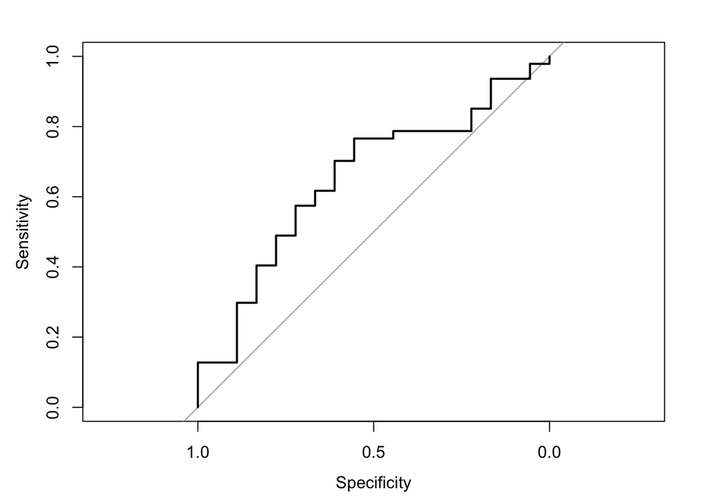

```r
# Presentar el modelo
plot(roc_curve)
```

Curva horrible…. el modelo predice muy mal..